# Factors

## Factors

A `factor` is a special `character` vector where the elements have pre-defined groups or ‘levels’. You can think of these as qualitative or categorical variables:

```r
x <- c("yellow", "red", "red", "blue", "yellow", "blue")
class(x)
```

```
## [1] "character"
```

```r
x_fact <- factor(x) # factor() is a function
class(x_fact)
```

```
## [1] "factor"
```

## Factors

Factors have **levels** (character types do not).

```r
x
```

```
## [1] "yellow" "red"    "red"    "blue"   "yellow" "blue"
```

```r
x_fact
```

```
## [1] yellow red    red    blue   yellow blue
## Levels: blue red yellow
```

Note that levels are, by default, in **alphanumerical** order.

## Factors - get the levels

Extract the levels of a `factor` vector using `levels()`:

```r
levels(x_fact)
```

```
## [1] "blue"   "red"    "yellow"
```

## A Factor Example

We will use data on student dropouts from the State of California during the 2016-2017 school year. More on this data can be found here: https://www.cde.ca.gov/ds/ad/filesdropouts.asp

To preserve school anonymity, “CDS_CODE” is used in place of the individual school’s name.

You can download the data from the JHU website here: http://jhudatascience.org/intro_to_r/data/dropouts.txt

```r
dropouts <- read_delim("http://jhudatascience.org/intro_to_r/data/dropouts.txt", delim = "\t")
dropouts
```

```
## # A tibble: 59,599 × 20
##    CDS_CODE  ETHNIC GENDER    E7    E8    E9   E10   E11   E12   EUS  ETOT    D7
##    <chr>      <dbl> <chr>  <dbl> <dbl> <dbl> <dbl> <dbl> <dbl> <dbl> <dbl> <dbl>
##  1 01100170…      1 M          0     0     0     0     1     1     0     2     0
##  2 01100170…      1 F          0     0     1     0     2     0     0     3     0
##  3 01100170…      2 M          0     0     0     0     0     1     0     1     0
##  4 01100170…      2 F          0     0     2     2     2     1     0     7     0
##  5 01100170…      3 M          0     0     0     1     0     0     0     1     0
##  6 01100170…      3 F          0     0     1     1     2     0     0     4     0
##  7 01100170…      4 M          0     0     0     1     0     0     0     1     0
##  8 01100170…      5 M          0     0    31    32    17    22     0   102     0
##  9 01100170…      5 F          0     0    26    34    30    20     0   110     0
## 10 01100170…      6 M          0     0    19    20    17    13     0    69     0
## # ℹ 59,589 more rows
## # ℹ 8 more variables: D8 <dbl>, D9 <dbl>, D10 <dbl>, D11 <dbl>, D12 <dbl>,
## #   DUS <dbl>, DTOT <dbl>, YEAR <dbl>
```

## Preparing the data

Group by each school and aggregate (sum):

```r
dropouts <-
  dropouts %>%
  group_by(CDS_CODE) %>%
  summarize(
    Freshman = sum(D9),
    Sophomore = sum(D10),
    Junior = sum(D11),
    Senior = sum(D12)
  )
dropouts
```

```
## # A tibble: 5,507 × 5
##    CDS_CODE       Freshman Sophomore Junior Senior
##    <chr>             <dbl>     <dbl>  <dbl>  <dbl>
##  1 01100170112607        1         1      0      1
##  2 01100170123968        0         0      0      0
##  3 01100170130401        3         5     12     24
##  4 01100170130419        1         2     13     36
##  5 01100170131581        0         0      0      0
##  6 01100176002000        0         0      0      0
##  7 01316090131755        0         0      0      0
##  8 01316170131763        0         0      0      2
##  9 01611190000001        0         1      0      1
## 10 01611190106401        0         0      0      0
## # ℹ 5,497 more rows
```

## Preparing the data

Pivot to long format:

```r
dropouts <-
  dropouts %>%
  pivot_longer(
    !CDS_CODE,
    names_to = "grade",
    values_to = "n_dropouts"
  )
dropouts
```

```
## # A tibble: 22,028 × 3
##    CDS_CODE       grade     n_dropouts
##    <chr>          <chr>          <dbl>
##  1 01100170112607 Freshman           1
##  2 01100170112607 Sophomore          1
##  3 01100170112607 Junior             0
##  4 01100170112607 Senior             1
##  5 01100170123968 Freshman           0
##  6 01100170123968 Sophomore          0
##  7 01100170123968 Junior             0
##  8 01100170123968 Senior             0
##  9 01100170130401 Freshman           3
## 10 01100170130401 Sophomore          5
## # ℹ 22,018 more rows
```

## The data

```r
head(dropouts)
```

```
## # A tibble: 6 × 3
##   CDS_CODE       grade     n_dropouts
##   <chr>          <chr>          <dbl>
## 1 01100170112607 Freshman           1
## 2 01100170112607 Sophomore          1
## 3 01100170112607 Junior             0
## 4 01100170112607 Senior             1
## 5 01100170123968 Freshman           0
## 6 01100170123968 Sophomore          0
```

Notice that `grade` is a `chr` variable. This indicates that the values are **character** strings.

R does not realize that there is any order related to the `grade` values. It will assume that it is **alphabetical**.

However, we know that the order is: **freshman**, **sophomore**, **junior**, **senior**.

## For the next steps, let’s take a subset of data.

```r
set.seed(123) # same random sample each time
dropouts_subset <- slice_sample(dropouts, n = 32)
dropouts_subset
```

```
## # A tibble: 32 × 3
##    CDS_CODE       grade     n_dropouts
##    <chr>          <chr>          <dbl>
##  1 45699716050231 Junior             0
##  2 45700036050330 Junior             0
##  3 12630401230069 Sophomore          0
##  4 09100900930131 Sophomore          1
##  5 15633216009179 Junior             0
##  6 33670330113647 Sophomore          0
##  7 19643941931823 Freshman           1
##  8 19647331933381 Sophomore          7
##  9 38684786062053 Senior             0
## 10 11626616007611 Freshman           0
## # ℹ 22 more rows
```

## Plot the data

Let’s make a plot first. We might not like the ordering on the x-axis, though.

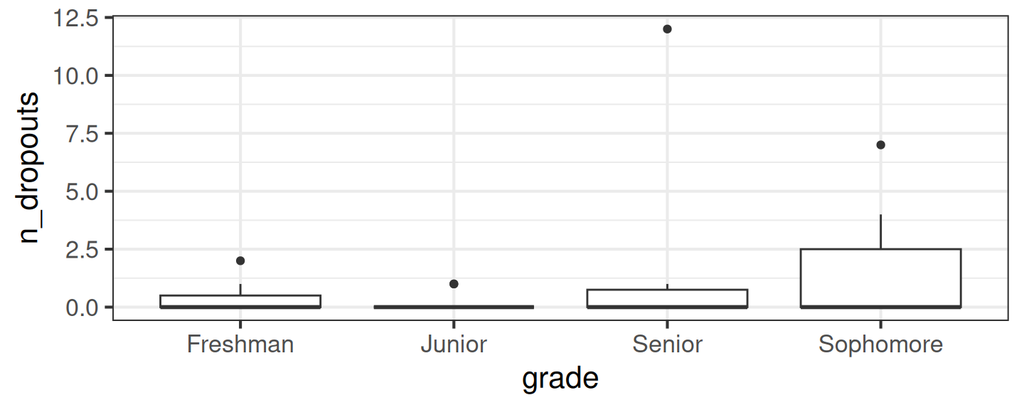

```r
dropouts_subset %>%
  ggplot(aes(x = grade, y = n_dropouts)) +
  geom_boxplot() +
  theme_bw(base_size = 16) # make all labels size 16
```

## Change to factor

Currently `grade` is class `character` but let’s change that to class `factor` which allows us to specify the levels or order of the values.

```r
dropouts_fct <-
  dropouts_subset %>%
  mutate(grade = factor(grade,
    levels = c("Freshman", "Sophomore", "Junior", "Senior")
  ))

dropouts_fct %>%
  pull(grade) %>%
  levels()
```

```
## [1] "Freshman"  "Sophomore" "Junior"    "Senior"
```

## Change to a factor

```r
head(dropouts_fct)
```

```
## # A tibble: 6 × 3
##   CDS_CODE       grade     n_dropouts
##   <chr>          <fct>          <dbl>
## 1 45699716050231 Junior             0
## 2 45700036050330 Junior             0
## 3 12630401230069 Sophomore          0
## 4 09100900930131 Sophomore          1
## 5 15633216009179 Junior             0
## 6 33670330113647 Sophomore          0
```

## Plot again

Now let’s make our plot again:

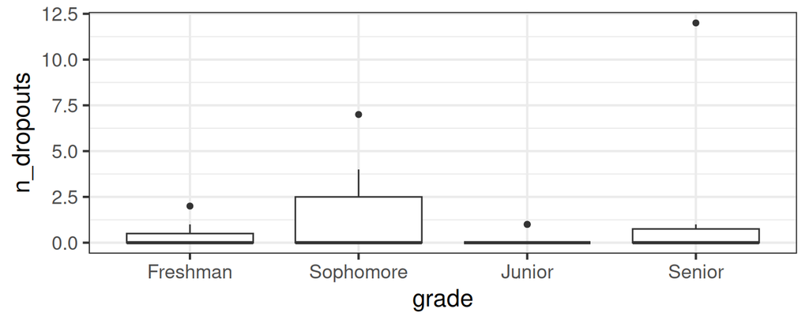

```r
dropouts_fct %>%
  ggplot(aes(x = grade, y = n_dropouts)) +
  geom_boxplot() +
  theme_bw(base_size = 16)
```

The factor data is automatically plotted in the order we would like.

## What about if we `arrange()` the data by grade ?

Character data is arranged alphabetically.

```r
dropouts_subset %>%
  arrange(grade)
```

```
## # A tibble: 32 × 3
##    CDS_CODE       grade    n_dropouts
##    <chr>          <chr>         <dbl>
##  1 19643941931823 Freshman          1
##  2 11626616007611 Freshman          0
##  3 23656150128280 Freshman          0
##  4 30664313030616 Freshman          0
##  5 54719935432414 Freshman          2
##  6 22655326025050 Freshman          0
##  7 37683386039911 Freshman          0
##  8 45699716050231 Junior            0
##  9 45700036050330 Junior            0
## 10 15633216009179 Junior            0
## # ℹ 22 more rows
```

Notice that the order is not what we would hope for!

## Arranging Factors

Factor data is arranged by level.

```r
dropouts_fct %>%
  arrange(grade)
```

```
## # A tibble: 32 × 3
##    CDS_CODE       grade     n_dropouts
##    <chr>          <fct>          <dbl>
##  1 19643941931823 Freshman           1
##  2 11626616007611 Freshman           0
##  3 23656150128280 Freshman           0
##  4 30664313030616 Freshman           0
##  5 54719935432414 Freshman           2
##  6 22655326025050 Freshman           0
##  7 37683386039911 Freshman           0
##  8 12630401230069 Sophomore          0
##  9 09100900930131 Sophomore          1
## 10 33670330113647 Sophomore          0
## # ℹ 22 more rows
```

Nice! Now this is what we would want!

## Making tables with characters

Tables grouped by a character are arranged alphabetically.

```r
dropouts_subset %>%
  group_by(grade) %>%
  summarize(total_dropouts = sum(n_dropouts))
```

```
## # A tibble: 4 × 2
##   grade     total_dropouts
##   <chr>              <dbl>
## 1 Freshman               3
## 2 Junior                 2
## 3 Senior                13
## 4 Sophomore             12
```

## Making tables with factors

Tables grouped by a factor are arranged by level.

```r
dropouts_fct %>%
  group_by(grade) %>%
  summarize(total_dropouts = sum(n_dropouts))
```

```
## # A tibble: 4 × 2
##   grade     total_dropouts
##   <fct>              <dbl>
## 1 Freshman               3
## 2 Sophomore             12
## 3 Junior                 2
## 4 Senior                13
```

## GUT CHECK: Why use factors?

A. Meaningful ordering of text data

B. Automatic ordering or numeric data

C. More precise values

## `forcats` package

A package called `forcats` is really helpful for working with factors.

## `forcats` for ordering

What if we wanted to order `grade` by increasing `n_dropouts`?

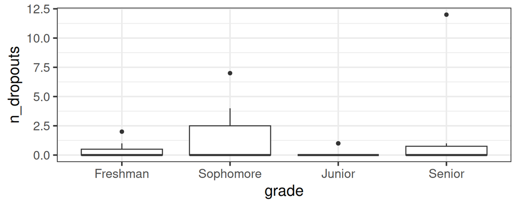

```r
library(forcats)

dropouts_fct %>%
  ggplot(aes(x = grade, y = n_dropouts)) +
  geom_boxplot() +
  theme_bw(base_size = 16)
```

This would be useful for identifying easily which grade to focus on.

## forcats for ordering

We can order a factor by another variable by using the `fct_reorder()` function of the `forcats` package.

```r
fct_reorder({column getting changed}, {guiding column}, {summarizing function})
```

## forcats for ordering

We can order a factor by another variable by using the `fct_reorder()` function of the `forcats` package.

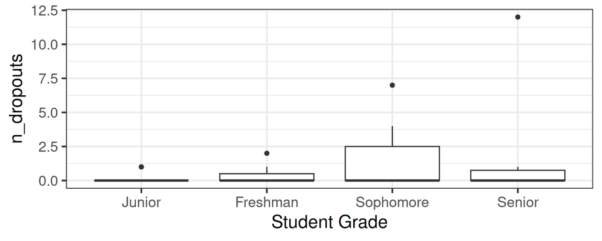

```r
library(forcats)

dropouts_fct %>%
  ggplot(aes(x = fct_reorder(grade, n_dropouts, mean), y = n_dropouts)) +
  geom_boxplot() +
  labs(x = "Student Grade") +
  theme_bw(base_size = 16)
```

## forcats for ordering.. with `.desc =` argument

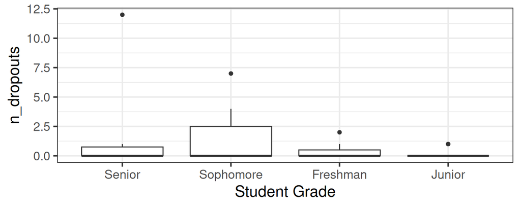

```r
library(forcats)

dropouts_fct %>%
  ggplot(aes(x = fct_reorder(grade, n_dropouts, mean, .desc = TRUE), y = n_dropouts)) +
  geom_boxplot() +
  labs(x = "Student Grade") +
  theme_bw(base_size = 16)
```

## Checking Proportions with `fct_count()`

The `fct_count()` function of the `forcats` package is helpful for checking that the proportions of each level for a factor are similar. Need the `prop = TRUE` argument otherwise just counts are reported.

```r
dropouts_fct %>%
  pull(grade) %>%
  fct_count(prop = TRUE)
```

```
## # A tibble: 4 × 3
##   f             n     p
##   <fct>     <int> <dbl>
## 1 Freshman      7 0.219
## 2 Sophomore     7 0.219
## 3 Junior       12 0.375
## 4 Senior        6 0.188
```

## Summary

- the factor class allows us to have a different order from alphanumeric for categorical data
- we can change data to be a factor variable using `mutate` and a factor creating function like `factor()` (alphabetical order by default)
- with `factor()` we can specify the levels with the `levels` argument if we want a specific order
- the `fct_reorder({variable_to_reorder}, {variable_to_order_by}, {summary function})` helps us reorder a variable by the values of another variable
- arranging, tabulating, and plotting the data will reflect the new order

## Lab

🏠 [Class Website](https://jhudatascience.org/intro_to_r/)

💻 [Lab](https://jhudatascience.org/intro_to_r/modules//Factors/lab/Factors_Lab.Rmd)

📃 [Day 7 Cheatsheet](https://jhudatascience.org/intro_to_r//modules/cheatsheets/Day-7.pdf)

📃 [Posit’s forcats cheatsheet](https://rstudio.github.io/cheatsheets/factors.pdf)